# Lab 3 - Matan Segal

## Life is Too Short to Drink Cheap Wine

#### Business understanding

The dataset token from: https://www.kaggle.com/uciml/red-wine-quality-cortez-et-al-2009

Originally, it was posted on the UCI machine learning repository: https://archive.ics.uci.edu/ml/datasets/wine+quality

Citation: P. Cortez, A. Cerdeira, F. Almeida, T. Matos and J. Reis. Modeling wine preferences by data mining from physicochemical properties. In Decision Support Systems, Elsevier, 47(4):547-553, 2009.

The dataset related to red variants of the Portuguese "Vinho Verde" wine. It contains 1599 different wines, which each have the following 11 features: fixed acidity, volatile acidity, citric acid, residual sugar, chlorides, free sulfur dioxide, total sulfur dioxide, density, pH, sulphates, and alcohol percentage. The target of the set is the quality of the wine, which is on scale of 0 to 10 (0 is very poor and 10 is an excellent wine). The measurement of the target was measured by sensors, which require several tests in a special lab and most importantly can be made just after making the wine.

The model I am claiming to build should use the features given to predict the quality of a wine before making it. the classification task is the scale of quality from 0 to 10. Based on the model, the wine producer should provide the required features for making the wine, and the model will return the predicted quality of the wine that will be made. Using the model, the producer will not need to wait until the end of the process of making the wine in order to measure the quality of the wine, but they will have a prediction even before starting the process.

The parties which will be interested in such a model will be the red wine producers as well as the wine stores that will be able to have a tool to measure the quality of the wine without the lab testing process.

For the model to be useful, it should have accuracy of at least 90%. In this case, the producers should use the model before the process of making the wine in order to set the features for best results, and at the end still make a quality checking for more accurate results.

### Prapering the Data

##### Data representation:

```python
import pandas as pd
import numpy as np

df = pd.read_csv('winequality-red.csv', encoding='unicode_escape', low_memory=True)

df.head()
```

|  | fixed acidity | volatile acidity | citric acid | residual sugar | chlorides | free sulfur dioxide | total sulfur dioxide | density | pH | sulphates | alcohol | quality |
| --- | --- | --- | --- | --- | --- | --- | --- | --- | --- | --- | --- | --- |
| 0 | 7.4 | 0.70 | 0.00 | 1.9 | 0.076 | 11.0 | 34.0 | 0.9978 | 3.51 | 0.56 | 9.4 | 5 |
| 1 | 7.8 | 0.88 | 0.00 | 2.6 | 0.098 | 25.0 | 67.0 | 0.9968 | 3.20 | 0.68 | 9.8 | 5 |
| 2 | 7.8 | 0.76 | 0.04 | 2.3 | 0.092 | 15.0 | 54.0 | 0.9970 | 3.26 | 0.65 | 9.8 | 5 |
| 3 | 11.2 | 0.28 | 0.56 | 1.9 | 0.075 | 17.0 | 60.0 | 0.9980 | 3.16 | 0.58 | 9.8 | 6 |
| 4 | 7.4 | 0.70 | 0.00 | 1.9 | 0.076 | 11.0 | 34.0 | 0.9978 | 3.51 | 0.56 | 9.4 | 5 |

```python
df.info()
```

```
<class 'pandas.core.frame.DataFrame'>
RangeIndex: 1599 entries, 0 to 1598
Data columns (total 12 columns):
fixed acidity           1599 non-null float64
volatile acidity        1599 non-null float64
citric acid             1599 non-null float64
residual sugar          1599 non-null float64
chlorides               1599 non-null float64
free sulfur dioxide     1599 non-null float64
total sulfur dioxide    1599 non-null float64
density                 1599 non-null float64
pH                      1599 non-null float64
sulphates               1599 non-null float64
alcohol                 1599 non-null float64
quality                 1599 non-null int64
dtypes: float64(11), int64(1)
memory usage: 150.0 KB
```

We can see that we have no missing data and that all of our values are numeric values that we can use for our training data as well as for tesing the data. I will use all the first 11 features for the data and the 'quality' column for the target. However, I will take the target and change it to one-hot encoding..

```python
X = (df.T[:11]).T
print('X shape:',X.shape)
Y_ = df['quality']
print('Unique values in Y:',np.unique(Y_))
```

```
X shape: (1599, 11)
Unique values in Y: [3 4 5 6 7 8]
```

In the quality column, we can see that there are actually values from 3 to 8, so our classification will be amoung 6 classes.

Now, I will check how many time each unique value appears:

```python
qualityList = [3, 4, 5, 6, 7, 8]
for i in range(6):
    print(qualityList[i],':',(df[df['quality'] == qualityList[i]]).shape[0])
```

```
3 : 10
4 : 53
5 : 681
6 : 638
7 : 199
8 : 18
```

Since qulity level 3 and 8 barely showed up, I will take them off and update X and Y

```python
df = df[~df['quality'].isin([3,8])]
print('df new shape:',df.shape)
X = (df.T[:11]).T
print('X shape:',X.shape)
Y = df['quality']
print('Unique values in Y:',np.unique(Y))
```

```
df new shape: (1571, 12)
X shape: (1571, 11)
Unique values in Y: [4 5 6 7]
```

```python
from sklearn.model_selection import train_test_split
X_train, X_test, Y_train, Y_test = train_test_split(X, Y, test_size=0.20, random_state=42)
print('X_train shape:',X_train.shape)
print('X_test shape:',X_test.shape)
print('Y_train shape:',Y_train.shape)
print('Y_test shape:',Y_test.shape)
```

```
X_train shape: (1256, 11)
X_test shape: (315, 11)
Y_train shape: (1256,)
Y_test shape: (315,)
```

```python
# one hot encoding
Y_train_1enc = pd.get_dummies(Y_train).values
Y_test_1enc = pd.get_dummies(Y_test).values

# counts values in Y train and test to see how many unique values
qualityList = [4, 5, 6, 7]
print('Y_test:')
for col in range(4):
    print(qualityList[col],':',sum(Y_test_1enc[:,col]))

print('\nY_train')
for col in range(4):
    print(qualityList[col],':',sum(Y_train_1enc[:,col]))
```

```
Y_test:
4 : 11
5 : 127
6 : 129
7 : 48

Y_train
4 : 42
5 : 554
6 : 509
7 : 151
```

In both, Y_train and Y_test we have approximation of normal distribution of the quality level. The test and the train sizes are acceptable for building a model and test it. In addition, the features used for prediction in the data are independent on one another and independent from raw to raw, therefore we can say that dividing our data into 20/80 precatage ratio is appropriate for my data set.

## Modeling

Steepest Descent, Stochastic Gradient Descent, Newton's method:

```python
from scipy.special import expit
from sklearn.metrics import accuracy_score
import random

class BinaryLR:
    # private:
    def __init__(self, eta, iterations = 20, C = 0.001, Reg = 'no',optTec = 'steepDes'):
        # optTech = optimization techinque [steepDes,SDG,newtons]
        self.eta = eta
        self.iters = iterations
        self.C = C
        self.reg = Reg
        self.ot = optTec

    @staticmethod
    def _add_bias(X):
        return np.hstack((np.ones((X.shape[0],1)),X)) # add bias term
    @staticmethod
    def _sigmoid(theta):
        # increase stability, redefine sigmoid operation
        return expit(theta) #1/(1+np.exp(-theta))

    def _get_gradient(self,X,y):
        # choose between the three

        if (self.ot == 'steepDes'):
            ydiff = y-self.predict_proba(X,add_bias=False).ravel() # get y difference
            gradient = np.mean(X * ydiff[:,np.newaxis], axis=0) # make ydiff a column vector and multiply through
            return gradient.reshape(self.w_.shape)

        elif (self.ot == 'SDG'):
            idx = int(np.random.rand()*len(y)) # grab random instance
            ydiff = y[idx]-self.predict_proba(X[idx],add_bias=False) # get y difference (now scalar)
            gradient = X[idx] * ydiff[:,np.newaxis] # make ydiff a column vector and multiply through

            gradient = gradient.reshape(self.w_.shape)
            gradient[1:] += -2 * self.w_[1:] * self.C

            return gradient

        elif (self.ot == 'newtons'):
            g = self.predict_proba(X,add_bias=False).ravel() # get sigmoid value for all classes
            hessian = X.T @ np.diag(g*(1-g)) @ X - 2 * self.C # calculate the hessian
            ydiff = y-g # get y difference
            gradient = np.sum(X * ydiff[:,np.newaxis], axis=0) # make ydiff a column vector and multiply through
            gradient = gradient.reshape(self.w_.shape)
            gradient[1:] += -2 * self.w_[1:] * self.C

            return pinv(hessian) @ gradient

    # public:
    def predict_proba(self, X, add_bias=True):
        # add bias term if requested
        Xb = self._add_bias(X) if add_bias else X
        return self._sigmoid(Xb @ self.w_) # return the probability y=1

    def fitBinary(self, X, y):
        Xb = self._add_bias(X) # add bias term
        num_samples, num_features = Xb.shape
        self.w_ = np.zeros((num_features,1)) # init weight vector to zeros
        # for as many as the max iterations
        for _ in range(self.iters):
            gradient = self._get_gradient(Xb,y)
            self.w_ += gradient*self.eta # multiply by learning rate
            # adding the regularization terms:
            if(self.reg == 'L1' or self.reg == 'L1L2'):
                self.w_[1:] -=self.eta*2*self.C*self.w_[1:] # update not include bias
            if(self.reg == 'L2' or self.reg == 'L1L2'):
                self.w_[1:] -=self.eta*self.C*abs(self.w_[1:])

class LR(BinaryLR):

    def __init__(self, eta, iterations = 20, C = 0.001, Reg = 'no', optTec = 'steepDes'):
        self.eta = eta
        self.iters = iterations
        self.C = C
        self.reg = Reg
        self.ot = optTec

    def fit(self,X,y):
        num_samples, num_features = X.shape
        self.unique_ = np.unique(y) # get each unique class value
        num_unique_classes = len(self.unique_)
        self.classifiers_ = [] # will fill this array with binary classifiers

        for i,yval in enumerate(self.unique_): # for each unique value
            y_binary = (y==yval) # create a binary problem
            # train the binary classifier for this class
            blr = BinaryLR(self.eta,self.iters,self.C,self.reg,self.ot)
            blr.fitBinary(X,y_binary)
            # add the trained classifier to the list
            self.classifiers_.append(blr)

        # save all the weights into one matrix, separate column for each class
        self.w_ = np.hstack([x.w_ for x in self.classifiers_]).T

    def predict_proba(self,X):
        probs = []
        for blr in self.classifiers_:
            probs.append(blr.predict_proba(X)) # get probability for each classifier
        return np.hstack(probs) # make into single matrix

    def predict(self,X):
        return self.unique_[np.argmax(self.predict_proba(X),axis=1)] # take argmax along row

#-----------------------------------------------------------------------------------------------
# testing the class:
# optTech = optimization techinque [steepDes,SDG,newtons]

lr = LR(0.001, 100, C=0.01, Reg = 'L1',optTec = 'steepDes')
lr.fit(X_train,Y_train)
yhat = lr.predict(X_test)
print('Accuracy of: ',accuracy_score(Y_test,yhat))
```

```
Accuracy of:  0.5015873015873016
```

One layer Neural Network (I added it because I thought it can be used as steepest desending, but it performed worse)

```python
class NerualNet1:
    def __init__(self, eta, iterations = 20, C = 0.001, Reg = 'no'):
        self.eta = eta
        self.iters = iterations
        self.C = C
        self.reg = Reg

    @staticmethod
    def _add_bias(X):
        return np.vstack((np.ones((1,X.shape[1])),X)) # add bias term as a row

    @staticmethod
    def _sigmoid(theta):
        return expit(theta) #1/(1+np.exp(-theta))

    # using one layer neural network
    def _get_gradient(self,X,y):
        yhat = self.predict_proba(X,add_bias=False) #yhat is the predicted value (= A2)
        V = (-2*(y - yhat)) * yhat * (1-yhat)
        return V @ X.T

    # public:
    def predict_proba(self,X,add_bias=True):
        # add bias term if requested
        Xb = self._add_bias(X) if add_bias else X
        return self._sigmoid(self.w_ @ Xb) # return the probability y=1

    def predict(self,X):
        A = X.T
        return self.unique_[np.argmax(self.predict_proba(A)>0.5,axis=0)]


    def fit(self, X, y):
        self.unique_ = np.unique(y)
        y = pd.get_dummies(y).values
        y = y.T
        A = X.T # make these as sets of columns samples
        A = self._add_bias(A) # add bias term
        num_features = A.shape[0]
        num_elems = y.shape[0]

        self.w_ = np.zeros((num_elems,num_features)) # init weight vector to zeros

        for _ in range(self.iters):
            gradient = self._get_gradient(A,y)
            self.w_ -= gradient*self.eta # multiply by learning rate
            if(self.reg == 'L1' or self.reg == 'L1L2'):
                self.w_[1:] -=self.eta*2*self.C*self.w_[1:] # update not include bias
            if(self.reg == 'L2' or self.reg == 'L1L2'):
                self.w_[1:] -=self.eta*self.C*abs(self.w_[1:])

#--------------------------------------------------------------------------

lr = NerualNet1(eta=0.05,iterations=200,C=0.01,Reg = 'L2')
lr.fit(X_train,Y_train)

yhat = lr.predict(X_test)

print('Accuracy of: ',accuracy_score(Y_test,yhat))
```

```
Accuracy of:  0.40634920634920635
```

Now I will write a function that will ask the user the kind of optimization technique as well as regularization type and the values of eta, iterations and C.

```python
def LogisticRegression(X_train,Y_train,X_test,Y_test,eta, iterations = 20, C = 0.01, Reg = 'no', optTech = 'steepDes'):
    # Reg = regularization [no,L1,L2,L1L2]
    # optTech = optimization techinque [steepDes,SDG,newtons,1NN] , where 1NN is one layer neural network
    lr = 0
    if(optTech == 'steepDes' or optTech == 'SDG' or optTech == 'newtons'):
        lr = LR(eta, iterations, C,Reg, optTech)
    elif(optTech == '1NN'):
        lr = NerualNet1(eta, iterations, C,Reg)
    else:
        print('Wrong input')
        return

    lr.fit(X_train,Y_train)
    yhat = lr.predict(X_test)
    return accuracy_score(Y_test,yhat)
```

Showing several results from running all the optimizations techmiques:

```python
tecList = ['steepDes','SDG']

for tec in tecList:
    acc = LogisticRegression(X_train,Y_train,X_test,Y_test,
                                          0.001, 100, C = 0.01,
                                          Reg = 'L1', optTech = tec)
    print('{:10s} {:7.2f} %.'.format(tec, acc * 100))

acc = LogisticRegression(X_train,Y_train,X_test,Y_test,
                                          0.001, 5, C = 0.01,
                                          Reg = 'L1L2', optTech = 'newtons')
print('{:10s} {:7.2f} %.'.format('newtons', acc * 100))

acc = LogisticRegression(X_train,Y_train,X_test,Y_test,
                                          0.1, 100, C = 0.01,
                                          Reg = 'L2', optTech = '1NN')
print('{:10s} {:7.2f} %.'.format('NN1', acc * 100))
```

```
steepDes     50.16 %.
SDG          44.13 %.
newtons      54.92 %.
NN1          40.32 %.
```

We can see that the best performance on the data is by the Newton's method.In order to check best performance overall, I will check for each one its performance with different values for eta and iters. For Newton's methos I will use small number of iteration.

```python
tecList = ['steepDes','SDG','1NN','newtons']

etaVals = [0.0001,0.001,0.01,0.1,1]
iterVals = [5,20,100,250]
newtoniter = [2,4,6,8]

steepDesList = []
SDGlist = []
newtonList = []
NN1List = []

listList = [steepDesList,SDGlist,NN1List,newtonList]

for o in range(3):
    print('\n-----------------',tecList[o],'------------------')
    for i in range(5):
        for j in range(4):
            acc = LogisticRegression(X_train,Y_train,X_test,Y_test,etaVals[i],
                                     iterVals[j], C = 0.01, Reg = 'L1L2',  optTech = tecList[o])* 100
            print('eta = {:5.4f}, iter = {:4d} , acc = {:3.2f} %.'.format(etaVals[i],iterVals[j], acc))
            listList[o].append(acc)

# newton
print('\n-----------------',tecList[3],'------------------')
for i in range(5):
    for j in range(4):
        acc = LogisticRegression(X_train,Y_train,X_test,Y_test,etaVals[i],
                                     newtoniter[j], C = 0.01, Reg = 'L1L2', optTech = tecList[3])* 100
        print('eta = {:5.4f}, iter = {:4d} , acc = {:3.2f} %.'.format(etaVals[i],newtoniter[j], acc))
        listList[3].append(acc)
```

```
----------------- steepDes ------------------
eta = 0.0001, iter =    5 , acc = 40.32 %.
eta = 0.0001, iter =   20 , acc = 40.32 %.
eta = 0.0001, iter =  100 , acc = 41.90 %.
eta = 0.0001, iter =  250 , acc = 46.98 %.
eta = 0.0010, iter =    5 , acc = 40.63 %.
eta = 0.0010, iter =   20 , acc = 43.49 %.
eta = 0.0010, iter =  100 , acc = 50.16 %.
eta = 0.0010, iter =  250 , acc = 49.52 %.
eta = 0.0100, iter =    5 , acc = 40.63 %.
eta = 0.0100, iter =   20 , acc = 40.95 %.
eta = 0.0100, iter =  100 , acc = 23.49 %.
eta = 0.0100, iter =  250 , acc = 39.37 %.
eta = 0.1000, iter =    5 , acc = 46.03 %.
eta = 0.1000, iter =   20 , acc = 13.97 %.
eta = 0.1000, iter =  100 , acc = 15.56 %.
eta = 0.1000, iter =  250 , acc = 9.21 %.
eta = 1.0000, iter =    5 , acc = 41.90 %.
eta = 1.0000, iter =   20 , acc = 21.27 %.
eta = 1.0000, iter =  100 , acc = 29.84 %.
eta = 1.0000, iter =  250 , acc = 18.73 %.

----------------- SDG ------------------
eta = 0.0001, iter =    5 , acc = 40.32 %.
eta = 0.0001, iter =   20 , acc = 40.32 %.
eta = 0.0001, iter =  100 , acc = 40.32 %.
eta = 0.0001, iter =  250 , acc = 40.32 %.
eta = 0.0010, iter =    5 , acc = 40.32 %.
eta = 0.0010, iter =   20 , acc = 40.32 %.
eta = 0.0010, iter =  100 , acc = 48.89 %.
eta = 0.0010, iter =  250 , acc = 40.32 %.
eta = 0.0100, iter =    5 , acc = 40.32 %.
eta = 0.0100, iter =   20 , acc = 40.00 %.
eta = 0.0100, iter =  100 , acc = 18.73 %.
eta = 0.0100, iter =  250 , acc = 43.17 %.
eta = 0.1000, iter =    5 , acc = 40.32 %.
eta = 0.1000, iter =   20 , acc = 15.24 %.
eta = 0.1000, iter =  100 , acc = 29.21 %.
eta = 0.1000, iter =  250 , acc = 39.37 %.
eta = 1.0000, iter =    5 , acc = 34.29 %.
```

[output cut: 32 more lines]

```
eta = 0.0010, iter =    4 , acc = 54.92 %.
eta = 0.0010, iter =    6 , acc = 54.92 %.
eta = 0.0010, iter =    8 , acc = 54.92 %.
eta = 0.0100, iter =    2 , acc = 54.60 %.
eta = 0.0100, iter =    4 , acc = 54.60 %.
eta = 0.0100, iter =    6 , acc = 54.29 %.
eta = 0.0100, iter =    8 , acc = 54.29 %.
eta = 0.1000, iter =    2 , acc = 56.83 %.
eta = 0.1000, iter =    4 , acc = 36.51 %.
eta = 0.1000, iter =    6 , acc = 10.16 %.
eta = 0.1000, iter =    8 , acc = 5.08 %.
eta = 1.0000, iter =    2 , acc = 40.32 %.
eta = 1.0000, iter =    4 , acc = 40.32 %.
eta = 1.0000, iter =    6 , acc = 40.32 %.
eta = 1.0000, iter =    8 , acc = 40.32 %.
```

Ploting the results:

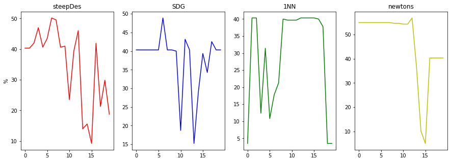

```python
import matplotlib.pyplot as plt

y = list(range(0,20))

fig, (ax1, ax2, ax3, ax4) = plt.subplots(1, 4, figsize=(15,5))

ax1.plot(y,listList[0],'r-')
ax2.plot(y,listList[1], 'b-')
ax3.plot(y,listList[2], 'g-')
ax4.plot(y,listList[3], 'y-')

ax1.title.set_text(tecList[0])
ax2.title.set_text(tecList[1])
ax3.title.set_text(tecList[2])
ax4.title.set_text(tecList[3])

ax1.set_ylabel('%')
plt.show()
```

After playing around with the best performance of the combination of the value of C and the kind of regularization I recieved that the Newton's method is defefnetly the best, with it best performance when eta = 0.1, number of iterations = 2 , we recieved accuracy of 56.83 %. However, the accuracy is still low.

Let's check how SKlearn algorithm for the logistic regression will perform on the data:

```python
%%time
from sklearn.linear_model import LogisticRegression as SKLogisticRegression

lr_sk = SKLogisticRegression(solver='liblinear')

lr_sk.fit(X_train,Y_train)
yhat = lr_sk.predict(X_test)
print('Accuracy of: ',accuracy_score(Y_test,yhat))
```

```
Accuracy of:  0.5428571428571428
Wall time: 24 ms
```

Sklearn performe a little worse than the Newton's method, but still better than all the other optimizattion techniques. Now, let's run again the best performance from above and see its performance time:

```python
%%time
lr = LR(0.1, 2, C=0.01, Reg = 'L1L2',optTec = 'newtons')
lr.fit(X_train,Y_train)
yhat = lr.predict(X_test)
print('Accuracy of: ',accuracy_score(Y_test,yhat))
```

```
Accuracy of:  0.5682539682539682
Wall time: 88 ms
```

The 2.6% between our Newton's method and the sklearn implementation cost us increasing in running time. Actually, our implementation is 4 time slower than sklearn. For this size of data set I would say it does not that effective, but for larger set it will definitely make a big different.

## Exceptional Work

**Buiulding Mean Square Error based model**

```python
class BinaryMSE:
    @staticmethod
    def _add_bias(X):
        return np.hstack((np.ones((X.shape[0],1)),X)) # add bias term

    @staticmethod
    def _sigmoid(theta):
        return expit(theta)

    def _get_w(self,X,y):
        return ((X.T@X)**-1)@X.T@y

    def predict_proba(self, X, add_bias=True):
        # add bias term if requested
        Xb = self._add_bias(X) if add_bias else X
        return self._sigmoid(Xb @ self.w_) # return the probability y=1

    def fitBinary(self, X, y):
        Xb = self._add_bias(X) # add bias term
        self.w_ = self._get_w(Xb,y)

class MSE:

    def fit(self,X,y):
        num_samples, num_features = X.shape
        self.unique_ = np.unique(y) # get each unique class value
        num_unique_classes = len(self.unique_)
        self.classifiers_ = [] # will fill this array with binary classifiers

        for i,yval in enumerate(self.unique_): # for each unique value
            y_binary = (y==yval) # create a binary problem
            # train the binary classifier for this class
            blr = BinaryMSE()
            blr.fitBinary(X,y_binary)
            # add the trained classifier to the list
            self.classifiers_.append(blr)

        # save all the weights into one matrix, separate column for each class
        self.w_ = np.hstack([x.w_ for x in self.classifiers_]).T

    def predict_proba(self,X):
        probs = []
        for blr in self.classifiers_:
            pred = blr.predict_proba(X)
            pred = pred.reshape((pred.shape[0],1)) #fixing the size since get (N,) instead of (N,1)
            probs.append(pred)
        return np.hstack(probs) # make into single matrix

    def predict(self,X):
        return self.unique_[np.argmax(self.predict_proba(X),axis=1)] # take argmax along row
```

```python
%%time
mse = MSE()
mse.fit(X_train,Y_train)
yhat = mse.predict(X_test)
print('Accuracy of: ',accuracy_score(Y_test,yhat))
```

```
Accuracy of:  0.4031746031746032
Wall time: 9 ms
```

We see that this way is actually the worst amoung all of our implamentations as well as sklearn, however it is the fastest. Considering the performance of all the other techniques on this spesific data, I will consider this way as acceptable way.